# Graphically Pawsitive Vibes

INFO 526 - Summer 2025 - Final Project

This project will graphically depict trends, patterns, and analysis of Animal Shelter data derived from the TidyTuesday initiative. The dataset includes information about animals taken in and released from the shelter; there are variables such as intake type, outcome type, animal type, breed, age, and more. The primary goal of this project is to identify key factors that influence an animals outcome.

Author

Affiliation

Isle of Dogs

School of Information, University of Arizona

# Graphically Pawsitive Vibes

### Data Loading

Load the Longbeach dataset from TidyTuesday

```
Rows: 29787
Columns: 22
```

```
 1. animal_id
 2. animal_name
 3. animal_type
 4. primary_color
 5. secondary_color
 6. sex
 7. dob
 8. intake_date
 9. intake_condition
10. intake_type
11. intake_subtype
12. reason_for_intake
13. outcome_date
14. crossing
15. jurisdiction
16. outcome_type
17. outcome_subtype
18. latitude
19. longitude
20. outcome_is_dead
21. was_outcome_alive
22. geopoint
```

## Abstract

This project examines factors influencing animal outcomes and adoption timelines at the Long Beach Animal Shelter. The dataset—sourced from TidyTuesday—contains 29,787 records and 22 fields, capturing intake and outcome events for various species in Long Beach, California.

The second goal examines how both the number of adoptions and the speed of adoption have changed from 2017 through 2024. We filter to records where `outcome_type == "adoption"`, compute `days_to_adoption` as the difference between `outcome_date` and `intake_date`, and derive `intake_year`. Vsualizations combine median adoption timelines with annual adoption counts to show how volumes and wait times have shifted year over year. This dual view reveals not just whether animals are moving through the shelter more quickly, but also whether adoption demand has increased or decreased, offering actionable insights for capacity planning, resource allocation, and ongoing performance benchmarking.

## Introduction

This project visualizes which intake scenarios and animal characteristics predict different outcomes, and how quickly animals find homes over time. By looking at a variety of visualizations, we hope to provide insight into how intake conditions and animal types affect the animal’s outcome and then examine year-by-year shifts in both the number of adoptions and the speed with which animals find homes. This information could deliver actionable insights for shelter staff on resource allocation and policy planning.

### Data Cleaning

Before diving into our analyses, we perform several key data‐wrangling steps to ensure consistency and create the variables we need. First, we standardize the `intake_condition` text by trimming extra whitespace, replacing slashes with spaces, and converting to lowercase. Next, we collapse the many values of `animal_type` into a three-level factor—Dog, Cat, and Other—so we can directly compare these groups. We also calculate each animal’s age at intake (in years) from its date of birth, flagging missing values as “Unknown.” Finally, we derive `days_to_adoption` by subtracting `intake_date` from `outcome_date`, which sets us up to explore adoption timelines.

#### Analysis of Data

To establish the rationale for combining `animal_type` into Dog, Cat, and Other, horizontal bar chart of the various values of `animal_type` are shown with color highlighting the grouping.

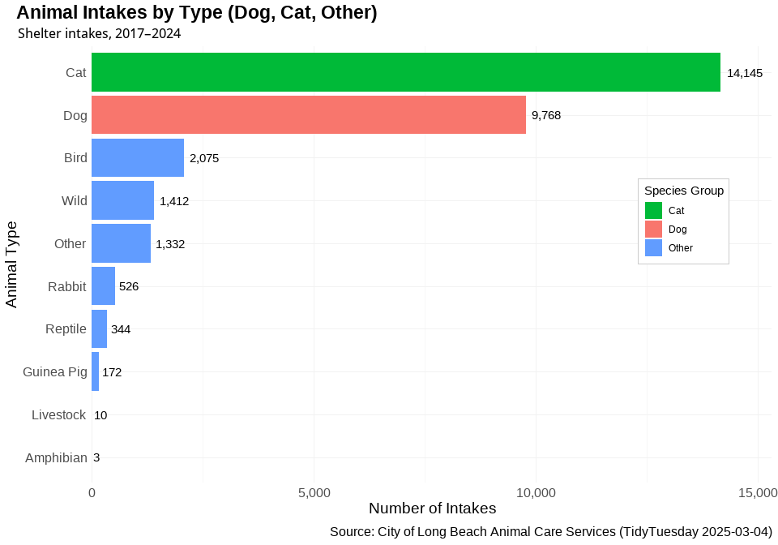

## Question 1: How do intake conditions and animal types affect the animal’s outcome?

### Introduction:

Animal shelters frequently intake a wide range of animals with different conditions. From scenarios such as healthy surrenders, injured or ill, or stray pickups. Understanding how these intake conditions affect the final outcomes across the three categorized animal types (dogs, cats, and others) is crucial. This analysis provides insights into which species may be underrepresented or disproportionately affected, helping shelter management and policymakers make informed decisions to improve animal care and resource allocation.

### Approach:

We will examine how `intake_condition` and `species_group` influence the likelihood of different outcomes for animals in the Long Beach shelter system. To simplify interpretation, the original `animal_type` variable has been recoded into a more general `species_group` category consisting of dogs, cats, and other species. This distinction allows us to focus on how outcomes differ not only by individual condition but also across species that historically experience different adoption rates and shelter outcomes.

The outcome variable, originally containing 19 unique `outcome_type` values, has been consolidated into a new `outcome_category` with three meaningful groups: **adopted**, **death**, and **non-death**. This categorization captures critical differences in outcomes while reducing complexity. Through this approach, we aim to uncover patterns that reveal which species and intake conditions are associated with better or worse outcomes, providing actionable insights for shelter management and animal welfare efforts.

### Analysis:

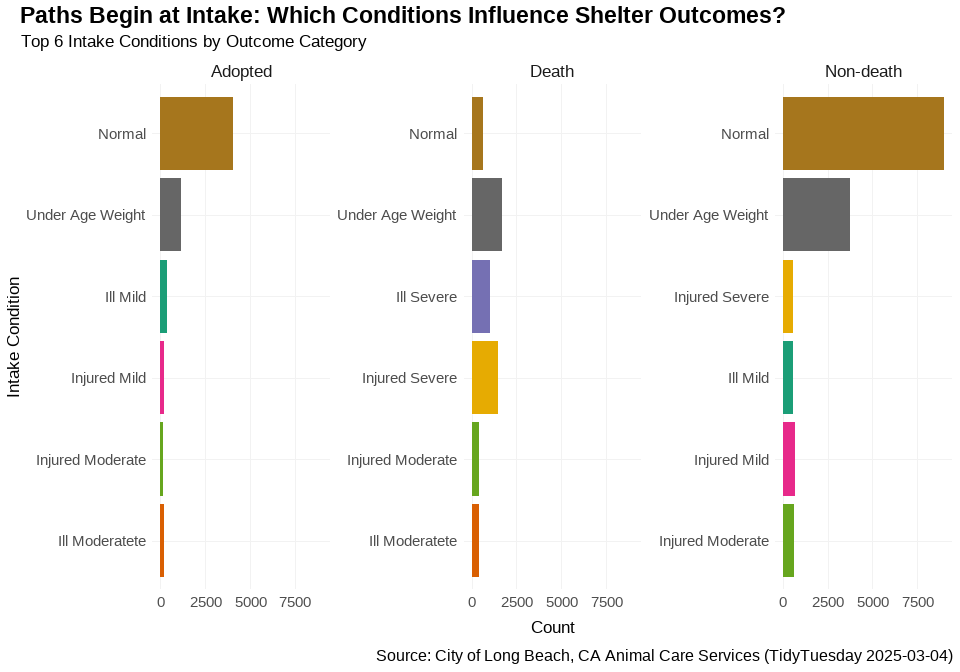

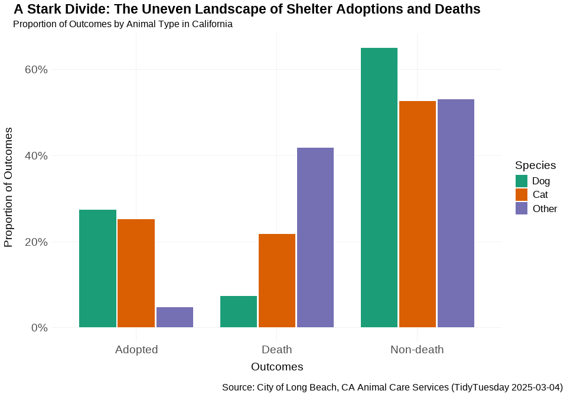

### Discussion:

The shelter outcome data reveals a clear disparity in how different species fare once admitted. Dogs and cats make up the majority of the shelter population, they are significantly more likely to be adopted compared to other species. This disproportionate rate of adoptions suggests that dogs and cats dominate intake numbers and benefit from greater public interest and adoption opportunities.

Conversely, animals categorized outside of dogs and cats, such as rabbits, birds, reptiles, and other small animals—experience far fewer adoptions and notably higher death rates. Despite representing a smaller share of shelter intakes, these species face worse outcomes, highlighting an underrepresented group that is more vulnerable within the shelter system.

## Question 2: How Have Adoption Volumes and Timelines Evolved (2017–2024) Across Dogs, Cats, and Other Species?

### Introduction:

Understanding how both the volume of adoptions and the speed at which animals leave the shelter have shifted from 2017 through 2024 is important for effective capacity planning and resource management. Looking at these trends out by Dogs, Cats, and Other species groups also lets us assess the impact of recent outreach and medical initiatives and inform future program investments.

### Approach:

The first plot shows, for each species group, how adoption volumes and delay distributions have shifted annually from 2017 through 2024. The grey bars (right‐axis scale) represent the total count of adoptions each year (scaled to the 95th percentile), while the blue violins (left‐axis scale) depict the full distribution of days-to-adoption, with dark points marking the median.

The second visualization consists of bubble chart plots, for each species group, the year‐to‐year relationship between the speed of adoptions (median days to adoption on the y-axis) and the volume of adoptions (bubble size). By faceting Dogs, Cats, and Other vertically, you can see how median wait times and total placements have moved in tandem from 2017 through 2024.

### Analysis:

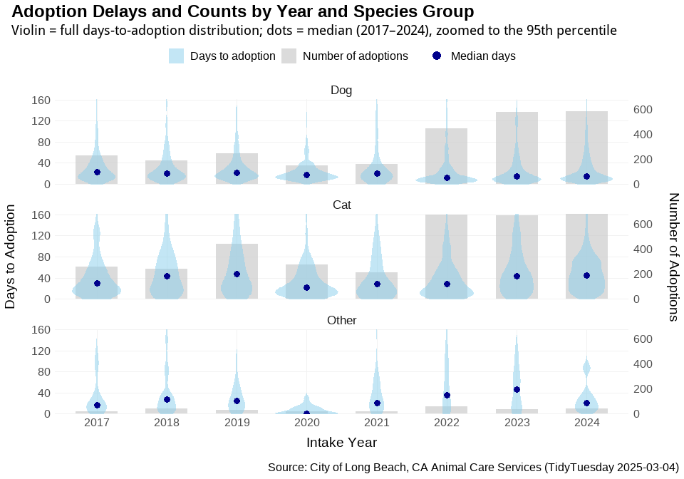

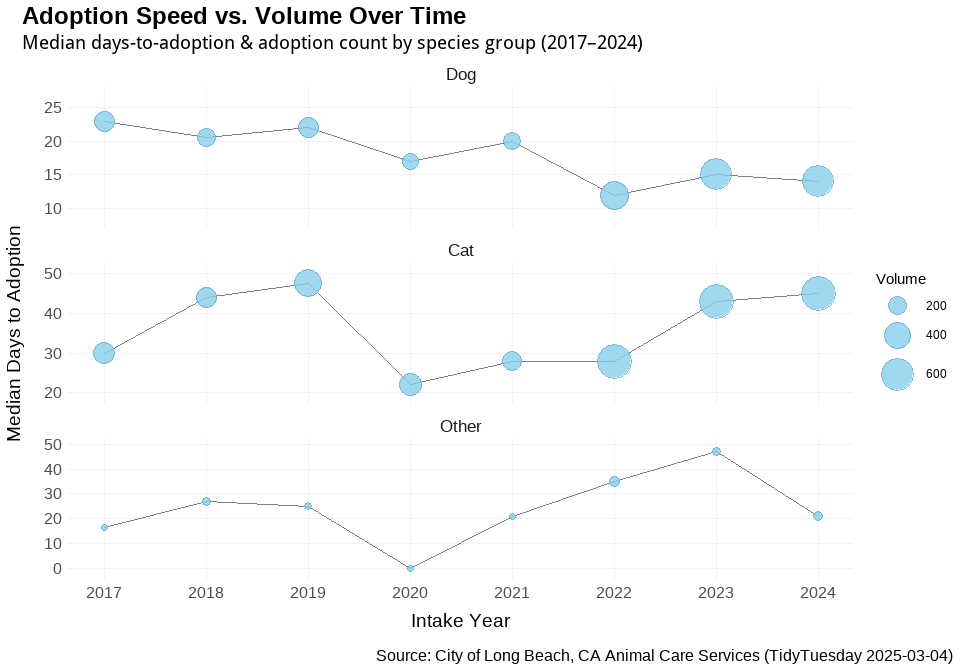

## Citations

AI was used for assistance in this project. It was used for code clarification, exception explanations, and discussions on how lubridate, scales, and other packages operate. Code snippets were used only when unable to resolve an issue independently. All text is written exclusively by the team.